# Working with Geospatial Data in R

```r
# install.packages("sf")
# install.packages("leaflet")
library(sf)
library(tidyverse)
```

Let’s load in our zipcode dataset. This is a geojson file, which was downloaded from https://data.nashville.gov/Metro-Government/Zip-Codes/72um-tmbe. Geosjson is a standard, based on JSON, for representing geographic features.

```r
zipcodes <- st_read('../data/zipcodes.geojson')
```

The actual object we read in is a simple feature collection, which means that it acts like a data frame, but it also contains additional geographic information.

```r
zipcodes
```

```
Simple feature collection with 57 features and 8 fields
Geometry type: MULTIPOLYGON
Dimension:     XY
Bounding box:  xmin: -87.05485 ymin: 35.96777 xmax: -86.5153 ymax: 36.4057
Geodetic CRS:  WGS 84
First 10 features:
   zipcode         poname created_date objectid                               globalid created_user
1    37218      NASHVILLE         <NA>       55 {3CB897BE-ACCB-46CB-BA4E-6F5E39D6C451}         <NA>
2    37080        JOELTON         <NA>       32 {C63ADE44-CC5E-4CCD-BBF0-4B8A64864B42}         <NA>
3    37027      BRENTWOOD         <NA>       44 {8846D4AC-5F8A-4434-8348-C9A28297FA4E}         <NA>
4    37086      LA VERGNE         <NA>        5 {1618FE99-089D-4ED0-BAFA-C29A19596F3D}         <NA>
5    37219      NASHVILLE         <NA>       15 {B531C81C-3919-4059-8444-23F5F0684ECA}         <NA>
6    37015   ASHLAND CITY         <NA>       21 {2AB8F204-63EE-49A4-A806-8E1DAE1C32AA}         <NA>
7    37143         PEGRAM         <NA>       23 {B142BE7A-6E4F-4325-95C5-A1C980D46F37}         <NA>
8    37072 GOODLETTSVILLE         <NA>       46 {FD866D5C-A196-4C6E-9CFF-A04FD08B1657}         <NA>
9    37189   WHITES CREEK         <NA>       50 {AD8029C0-DF92-4103-B4DF-A67EF4F502E1}         <NA>
10   37015   ASHLAND CITY         <NA>       20 {49D81E1C-5F08-414E-AED7-8C8F9714DD83}         <NA>
   last_edited_date last_edited_user                       geometry
1              <NA>             <NA> MULTIPOLYGON (((-86.88231 3...
2              <NA>             <NA> MULTIPOLYGON (((-86.90742 3...
3              <NA>             <NA> MULTIPOLYGON (((-86.67793 3...
4              <NA>             <NA> MULTIPOLYGON (((-86.5887 36...
5              <NA>             <NA> MULTIPOLYGON (((-86.78609 3...
6              <NA>             <NA> MULTIPOLYGON (((-86.88867 3...
7              <NA>             <NA> MULTIPOLYGON (((-87.03553 3...
8              <NA>             <NA> MULTIPOLYGON (((-86.76191 3...
9              <NA>             <NA> MULTIPOLYGON (((-86.844 36....
10             <NA>             <NA> MULTIPOLYGON (((-86.92773 3...
```

We can create plots out of our geospatial data using ggplot.

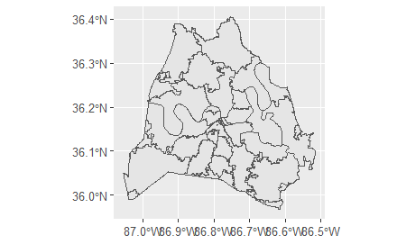

```r
zipcodes |>
  ggplot() +
  geom_sf()
```

We can adjust the color using the fill aesthethic.

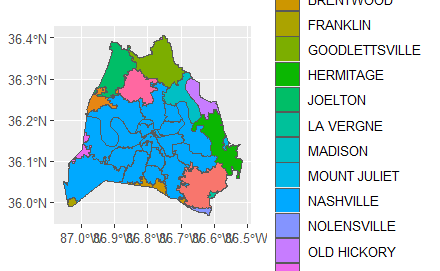

```r
zipcodes |>
  ggplot() +
  geom_sf(aes(fill = poname))
```

We might also want to work with data in the form a csv file.

```r
bus_stops <- read_csv("../data/WeGo_Transit_Bus_Stops_20231025.csv")
bus_stops
```

| Stop ID | Stop Abbreviation | Stop Name | Shelter? | Bench? | Route Numbers | Route Name | Mapped Location |
| --- | --- | --- | --- | --- | --- | --- | --- |
| 5120 | 7AVUNINN | 7TH AVE & UNION ST NB | FALSE | FALSE | NA | AIRPORT - DOWNTOWN HOTELS | NA |
| 5455 | CM5_4 | Temporary Bay 4 | FALSE | FALSE | NA | HERMAN | NA |
| 2762 | 23ACLASF | 23RD AVE N & CLARKSVILLE PIKE SB | FALSE | FALSE | 2.200000e+01 | BORDEAUX | NA |
| 4079 | 21ACHUSN | 21ST AVE N & CHURCH ST SB | FALSE | TRUE | 2.500000e+01 | MIDTOWN | NA |
| 4133 | GRWHIWN | GREEN LN & WHITES CREEK PIKE WB | FALSE | FALSE | 4.100000e+01 | GOLDEN VALLEY | (36.236249, -86.816722) |
| 4083 | Z9AEDGSN | _ 9TH AVE S & EDGEHILL AVE SB | FALSE | FALSE | 8.000000e+00 | 8TH AVENUE SOUTH | (36.142642, -86.780897) |
| 5066 | MXODONEL | DONELSON/DELL STATION OUTBOUND | TRUE | FALSE | 1.555000e+03 | MURFREESBORO PIKE | (36.105615, -86.672004) |
| 94 | 17ADORSN | 17TH AVE S & DOROTHY PL SB | FALSE | FALSE | 2.000000e+00 | BELMONT | (36.137623, -86.795609) |
| 3219 | COC14AWN | COCKRILL ST & 14TH AVE N | FALSE | FALSE | 4.200000e+01 | ST. CECILIA - CUMBERLAND | (36.175944, -86.804242) |
| 4842 | WED18AWN | WEDGEWOOD AVE & 18TH AVE S WB | FALSE | FALSE | 2.100000e+01 | UNIVERSITY CONNECTOR | (36.137212, -86.796865) |

[output cut: 990 more lines]

Let’s extract the latitude and longitude using the str_extract function from stringr.

```r
bus_stops <- bus_stops |>
  mutate(
    latitude = as.numeric(str_extract(`Mapped Location`, "\\((.+),", group = 1)),
    longitude = as.numeric(str_extract(`Mapped Location`, ",(.+)\\)", group = 1))
    )

bus_stops |> head(5)
```

| Stop ID | Stop Abbreviation | Stop Name | Shelter? | Bench? | Route Numbers | Route Name | Mapped Location | latitude | longitude |
| --- | --- | --- | --- | --- | --- | --- | --- | --- | --- |
| 5120 | 7AVUNINN | 7TH AVE & UNION ST NB | FALSE | FALSE | NA | AIRPORT - DOWNTOWN HOTELS | NA | NA | NA |
| 5455 | CM5_4 | Temporary Bay 4 | FALSE | FALSE | NA | HERMAN | NA | NA | NA |
| 2762 | 23ACLASF | 23RD AVE N & CLARKSVILLE PIKE SB | FALSE | FALSE | 22 | BORDEAUX | NA | NA | NA |
| 4079 | 21ACHUSN | 21ST AVE N & CHURCH ST SB | FALSE | TRUE | 25 | MIDTOWN | NA | NA | NA |
| 4133 | GRWHIWN | GREEN LN & WHITES CREEK PIKE WB | FALSE | FALSE | 41 | GOLDEN VALLEY | (36.236249, -86.816722) | 36.23625 | -86.81672 |

Now, we can plot these bus stops. Note that I’ll start with the zipcodes plot and then add in the bus stops by using geom_point.

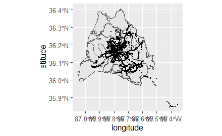

```r
zipcodes |>
  ggplot() +
  geom_sf() +
  geom_point(
    data = bus_stops |> drop_na(latitude),
    aes(x = longitude, y = latitude),
    size = 0.1
    )
```

It appears that some of the bus stops are outside of Davidson County. What if we want to select only those inside the county?

If we want to be able to perform geospatial operations on our bus stops, we need to convert it into a geospatial object. We can do this using the st_as_sf function.

```r
bus_stops_geo <- st_as_sf(
  bus_stops |> drop_na(latitude),
  coords = c('longitude', 'latitude'),
  crs = st_crs(zipcodes)
)
```

Now, to build our plot, we can use geom_sf.

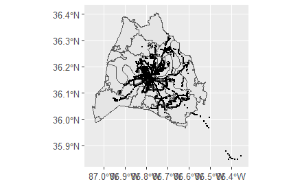

```r
zipcodes |>
  ggplot() +
  geom_sf() +
  geom_sf(data = bus_stops_geo, size = 0.1)
```

```r
bus_zips <- st_join(bus_stops_geo, zipcodes, join = st_within)
bus_zips
```

```
Simple feature collection with 2524 features and 16 fields
Geometry type: POINT
Dimension:     XY
Bounding box:  xmin: -86.95566 ymin: 35.84744 xmax: -86.35178 ymax: 36.32447
Geodetic CRS:  WGS 84
```

|  | Stop ID | Stop Abbreviation | Stop Name | Shelter? | Bench? | Route Numbers | Route Name | Mapped Location | geometry | zipcode | poname | created_date | objectid | globalid | created_user | last_edited_date | last_edited_user |
| --- | --- | --- | --- | --- | --- | --- | --- | --- | --- | --- | --- | --- | --- | --- | --- | --- | --- |
| 1 | 4133 | GRWHIWN | GREEN LN & WHITES CREEK PIKE WB | FALSE | FALSE | 4.100000e+01 | GOLDEN VALLEY | (36.236249, -86.816722) |  | 37189 | WHITES CREEK | NA | 50 | {AD8029C0-DF92-4103-B4DF-A67EF4F502E1} | NA | NA | NA |
| 2 | 4083 | Z9AEDGSN | _ 9TH AVE S & EDGEHILL AVE SB | FALSE | FALSE | 8.000000e+00 | 8TH AVENUE SOUTH | (36.142642, -86.780897) |  | 37203 | NASHVILLE | NA | 33 | {0C5DE6D7-6108-445E-8738-5FE7E08E3F6B} | NA | NA | NA |
| 3 | 5066 | MXODONEL | DONELSON/DELL STATION OUTBOUND | TRUE | FALSE | 1.555000e+03 | MURFREESBORO PIKE | (36.105615, -86.672004) |  | 37217 | NASHVILLE | NA | 56 | {55AA0665-B3D0-4F9B-A017-738CF4777049} | NA | NA | NA |
| 4 | 94 | 17ADORSN | 17TH AVE S & DOROTHY PL SB | FALSE | FALSE | 2.000000e+00 | BELMONT | (36.137623, -86.795609) |  | 37212 | NASHVILLE | NA | 54 | {F41243FF-142E-44A5-A6CC-99FE8DED45AD} | NA | NA | NA |
| 5 | 3219 | COC14AWN | COCKRILL ST & 14TH AVE N | FALSE | FALSE | 4.200000e+01 | ST. CECILIA - CUMBERLAND | (36.175944, -86.804242) |  | 37208 | NASHVILLE | NA | 37 | {CF9166C1-A8AA-4DEA-9601-9DE6C525DFFF} | NA | NA | NA |
| 6 | 4842 | WED18AWN | WEDGEWOOD AVE & 18TH AVE S WB | FALSE | FALSE | 2.100000e+01 | UNIVERSITY CONNECTOR | (36.137212, -86.796865) |  | 37212 | NASHVILLE | NA | 54 | {F41243FF-142E-44A5-A6CC-99FE8DED45AD} | NA | NA | NA |
| 7 | 1393 | MAI7SEN | MAIN ST & N 7TH ST EB | FALSE | TRUE | 2.630000e+03 | GALLATIN PIKE | (36.174379, -86.761018) |  | 37206 | NASHVILLE | NA | 2 | {E98044D0-5348-4368-8048-06782FF961B6} | NA | NA | NA |
| 8 | 46 | 12ALAWNN | 12TH AVE S & LAWRENCE AVE NB | FALSE | FALSE | 1.700000e+01 | 12TH AVENUE SOUTH | (36.129319, -86.788814) |  | 37204 | NASHVILLE | NA | 9 | {088860BD-8E49-46FE-B035-CB401BBDA2F6} | NA | NA | NA |
| 9 | 4351 | FAILEWWn | FAIN ST & LEWIS ST WB | FALSE | FALSE | 2.500000e+01 | MIDTOWN | (36.1518, -86.757849) |  | 37210 | NASHVILLE | NA | 12 | {0F9F7F39-9683-4872-92E9-9D8527FC760D} | NA | NA | NA |
| 10 | 4954 | DOVMOOEF | DOVERSIDE DR & MOORWOOD DR EB | FALSE | FALSE | 2.300000e+01 | DICKERSON ROAD | (36.240342, -86.772854) |  | 37207 | NASHVILLE | NA | 48 | {9B931215-5390-4FCF-BDF4-9B017000CF27} | NA | NA | NA |

[output cut: 990 more lines]

Notice that bus_zips retains the geometry of bus_stops, as this was the first dataframe we provided. Now, we can, for example, count the number of stops per zipcode. Note that when performing calculations on an sf object, it is usually quicker if you drop the geometry first.

```r
bus_zips |>
  st_drop_geometry() |>
  group_by(zipcode) |>
  count(name = "num_stops") |>
  arrange(desc(num_stops))
```

| zipcode | num_stops |
| --- | --- |
| 37207 | 272 |
| 37203 | 237 |
| 37206 | 205 |
| 37211 | 174 |
| 37208 | 165 |
| 37209 | 149 |
| 37210 | 141 |
| 37217 | 121 |
| 37115 | 106 |
| 37013 | 103 |

[output cut: 19 more lines]

Now, we can plot the bus stops contained in a given zipcode.

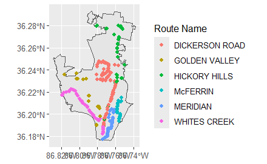

```r
zip = 37207

zipcodes |>
  filter(zipcode == zip) |>
  ggplot() +
  geom_sf() +
  geom_sf(data = bus_zips |> filter(zipcode == zip),
          aes(color = `Route Name`))
```

```r
leaflet(data = bus_stops |>
          drop_na(latitude) |>
          filter(`Route Name` == "WEST END - WHITE BRIDGE")
        ) |>
  addTiles() |>
  addMarkers(~longitude,
             ~latitude,
             popup = ~as.character(`Stop Name`),
             label = ~as.character(`Stop Name`)
             )
```

[output not shown]

You can also do marker clusters.